# visualization_lecture

mggn

10/5/2020

### Notes pre-coding segment

-exploratory data analysis includes visualization, checks for data completeness and reliability -quantification of centrality and variability -initial evaluation of hypothesis and hypothesis generation -looking at data is critical -make dozens of graphics for each dataset

GGPLOT -makes graphics with relative ease -cohesiveness, same principles underlie all graphic types -start google searches with ‘ggplot’ -basic graph components: data, aesthetic mappings, geoms -advanced graph components: facets, scales, statistics -combining these components build a graph

### time to code

```r
library(tidyverse)
library(ggridges)
```

-rnoaa allows us to pull data from online so part one is essentially “bring me that data” and then the part in mutate is just data manipulation then select to make sure that the order is as I want it

```r
weather_df =
  rnoaa::meteo_pull_monitors(
    c("USW00094728", "USC00519397", "USS0023B17S"),
    var = c("PRCP", "TMIN", "TMAX"),
    date_min = "2017-01-01",
    date_max = "2017-12-31") %>%
  mutate(
    name = recode(
      id,
      USW00094728 = "CentralPark_NY",
      USC00519397 = "Waikiki_HA",
      USS0023B17S = "Waterhole_WA"),
    tmin = tmin / 10,
    tmax = tmax / 10) %>%
  select(name, id, everything())
```

```
## using cached file: C:\Users\MariaGuzman\AppData\Local\Cache/R/noaa_ghcnd/USW00094728.dly
```

```
## date created (size, mb): 2020-10-05 15:07:44 (7.537)
```

```
## file min/max dates: 1869-01-01 / 2020-10-31
```

```
## using cached file: C:\Users\MariaGuzman\AppData\Local\Cache/R/noaa_ghcnd/USC00519397.dly
```

```
## date created (size, mb): 2020-10-05 15:08:03 (1.703)
```

```
## file min/max dates: 1965-01-01 / 2020-03-31
```

```
## using cached file: C:\Users\MariaGuzman\AppData\Local\Cache/R/noaa_ghcnd/USS0023B17S.dly
```

```
## date created (size, mb): 2020-10-05 15:08:11 (0.882)
```

```
## file min/max dates: 1999-09-01 / 2020-10-31
```

### creating scatterplots

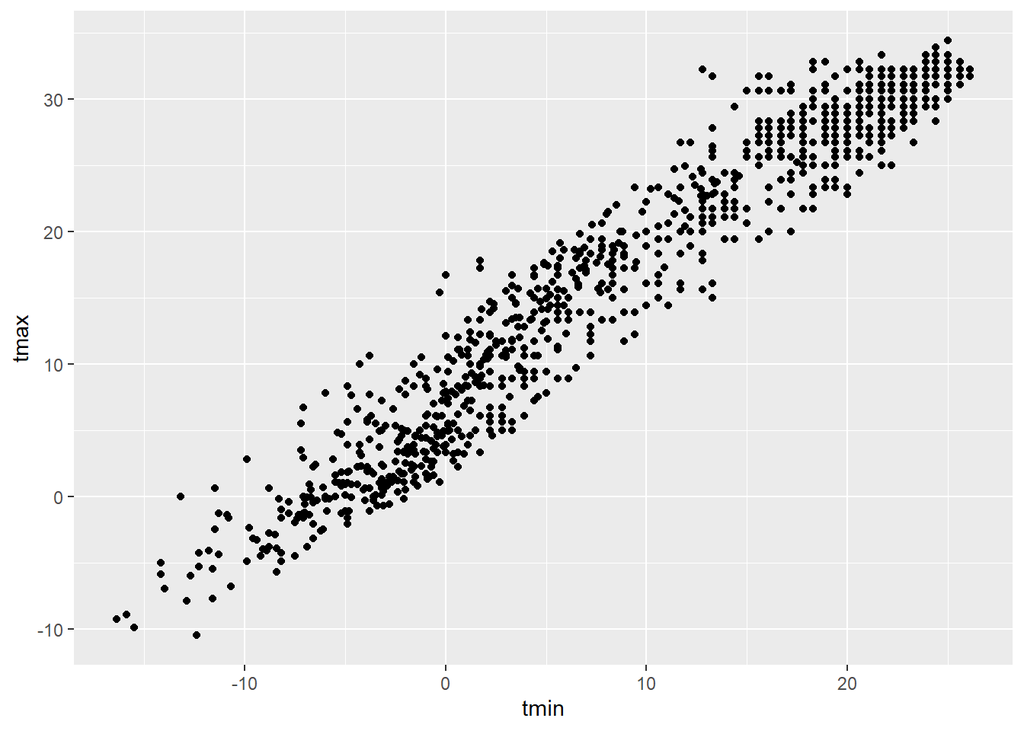

```r
##new approach same plot
weather_df %>%
  ggplot(aes(x = tmin, y = tmax))+
  geom_point()
```

save and edit a plot object

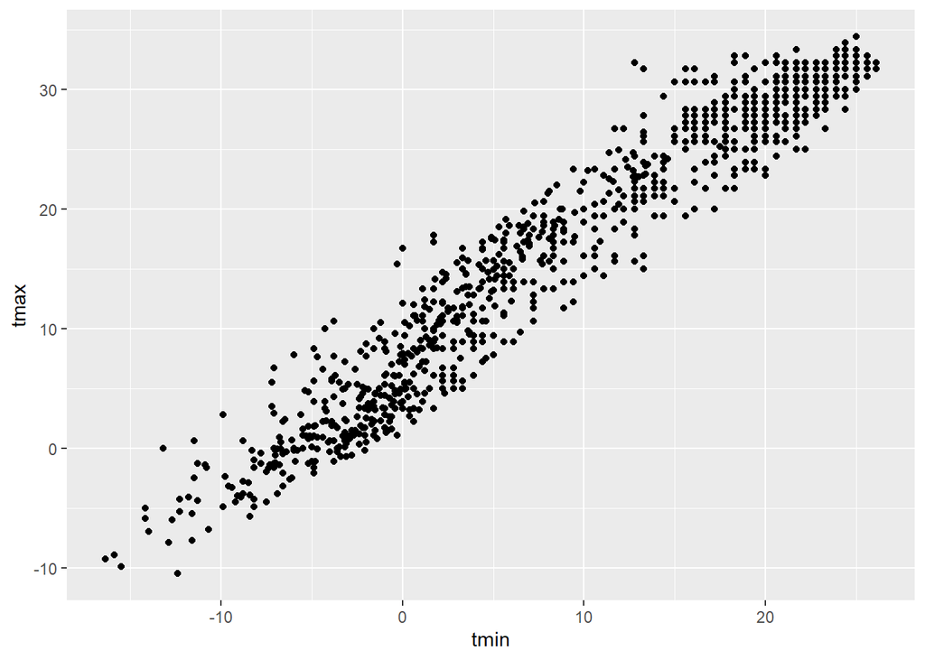

```r
weather_plot =
  weather_df %>%
  ggplot(aes(x = tmin, y = tmax))

weather_plot + geom_point()
```

let’s get fancy

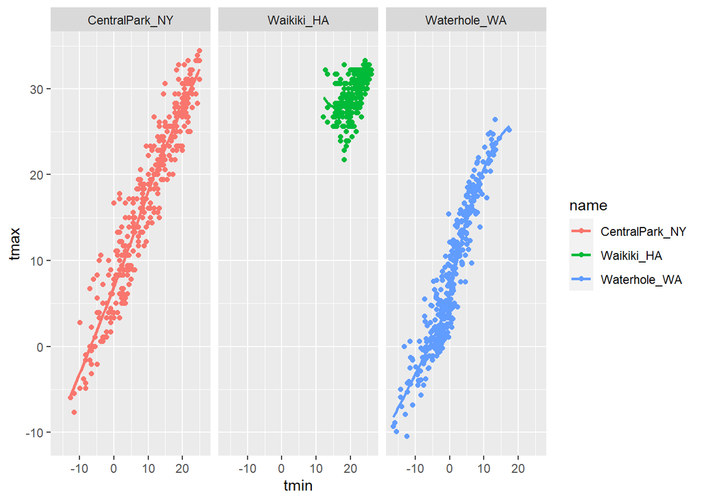

```r
weather_df %>%
  ggplot(aes(x = tmin, y = tmax, color = name)) +
  geom_point() +
  geom_smooth(se = FALSE)+
  facet_grid(. ~name)
```

## some small notes

How many geoms have to exist? you can have whatever geoms you want **but in general it is good to show the data points with geom_point

## univariate plots

Histograms are neat, we can also make box plots trendy plots include geom_violin also ridge plots, aka the most popular plot of 2017 (need to load ggridges package)

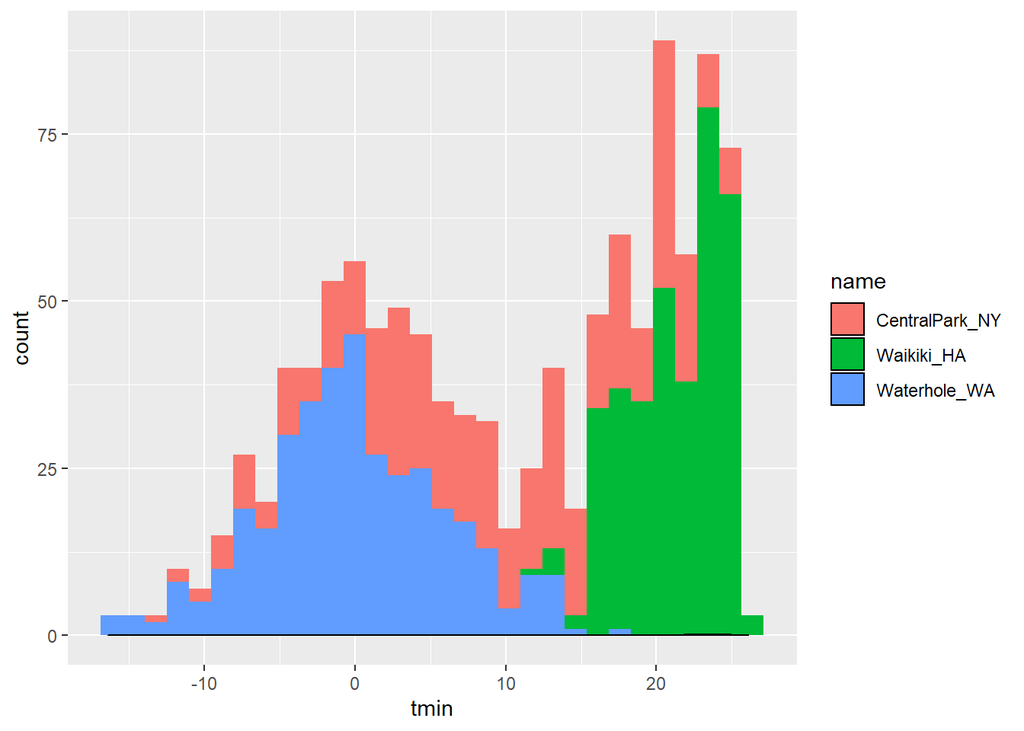

```r
weather_df %>%
  ggplot(aes(x = tmin, fill = name))+
  geom_histogram()+
  geom_density(alpha = .3)
```